# Family Background and Mathematics Performance in PISA 2025

by α-R: Junyi Mao, Pang-Qiyu, Ziqiao Zhou, Ali Hamzeh & Yachen Wang

2026-11-26

## Introduction

### Research Question

**Question**: *How are parental education, parental occupational status, and home ICT resources associated with students’ mathematics performance in PISA 2025?*

**Why**: *Students’ home environments may play an important role in their educational outcomes. Differences in parental education, occupational status, and access to ICT resources may be associated with students’ opportunities to learn and their mathematics performance. Investigating these relationships can help us better understand how family background relates to educational achievement.*

### Dataset overview

*This investigation uses student-level data from the PISA 2025 Student Questionnaire, published by the Organisation for Economic Co-operation and Development (OECD). The dataset contains information on students’ backgrounds and mathematics performance, allowing us to investigate the associations between family circumstances and academic achievement (OECD, n.d.).*

## Methods

### Key variables

Our investigation focuses on three main factors that may be related to students’ mathematics performance.

Mathematics performance: math_score represents each student’s mathematics performance.

Parental education: We use parental_education_years to show the number of years of education completed by parents. We also kept highest_parental_education in the dataset.

Parental occupational status: We use highest_parental_occupational_status to examine whether parents’ occupational status is related to students’ mathematics performance.

Home ICT resources: We use home_ict_resources to represent the ICT resources available at home.

Other variables, such as student age, gender, country, family socioeconomic status and home possessions, were also kept to provide more information about students’ backgrounds.

### Data processing

Our starting material came in two parts: the PISA 2025 data file and the student questionnaire. We worked from the data file only, so the questionnaire was set aside and everything below is based on the 755,721 student rows in `student_math`.

We first used `summary()` in R to check the data and identify missing values. Mathematics scores were missing for two countries, so we excluded them: Uzbekistan (all of its records) and Belgium (one record). That took out 8,653 records, leaving 747,068 students.

To make the data easier to use, we calculated the average of the ten mathematics scores for each student using `rowMeans()`. We created a new variable called `math_score` and then removed the original ten score columns.

We then selected the variables needed for our research: mathematics scores, parental education, parental occupational status and home ICT resources.

We did not remove all missing values from the other variables at this stage. Instead, we excluded missing observations when needed for individual visualisations and analyses, so that each analysis kept as many students as its own variables allowed, rather than losing rows it did not use.

### Data citation

The dataset was retrieved on 28 October 2026 from the OECD PISA 2025 database: https://webfs.oecd.org/pisa2022/index.html.

## Results

As a preliminary analysis, we used the processed dataset to visualize the distribution of students’ mathematics scores, as seen in Figure 1.

### **Figure 1**

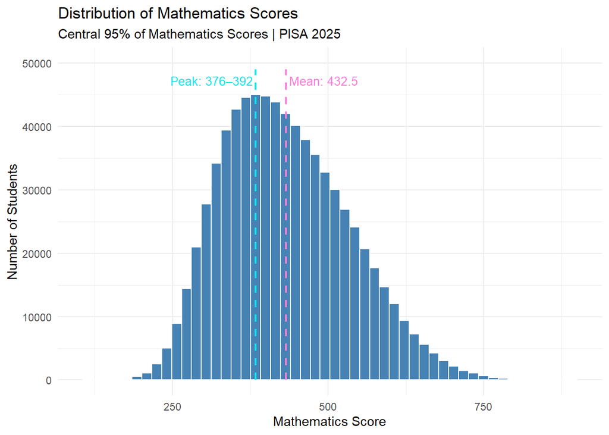

*Note.* This figure is a frequency histogram showing the distribution of mathematics scores across the PISA 2025 dataset.

After analyzing the overall data, we moved on to explore the individual variables’ relationship with mathematics score, starting with parental education (measured as the highest number of years of education attained by either parent). This data was divided into five levels (6, 9, 12, 14, 16) in PISA 2025, determined using the ISCED international standard (OECD, 2026).

Figure 2 shows a visualization of distribution of mathematics scores across these five groups. The plot suggests a possible positive correlation between students’ mathematics scores and parental education years.

### **Figure 2**

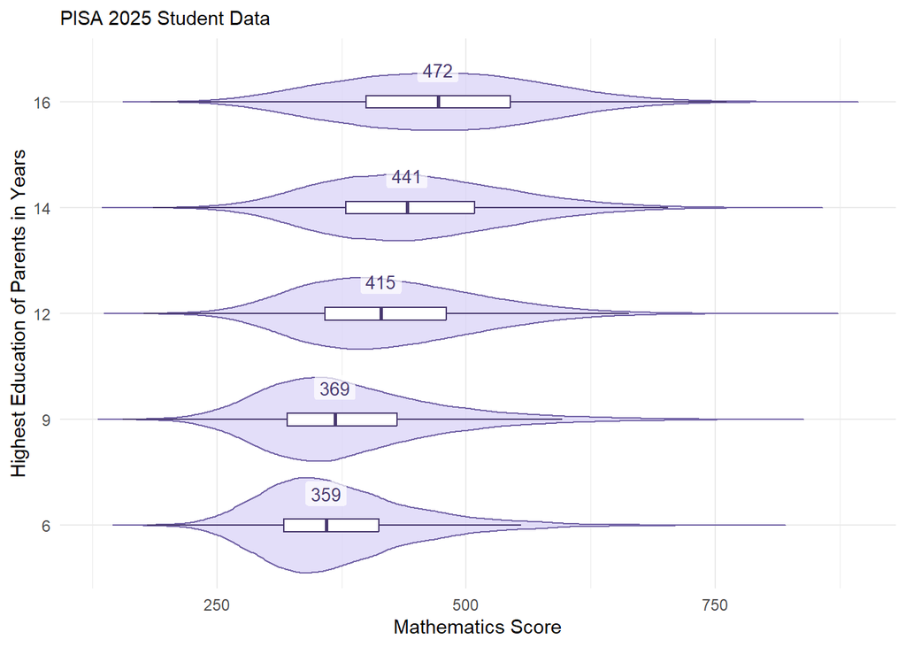

*Note.* This figure is a violin plot combined with boxplots, showing the distribution of mathematics scores for each level of highest parental education, in the PISA 2025 dataset.

The next variable analyzed in relation to mathematics performance was highest parental occupational status, visualized as a hexagonal bin plot with a linear regression line in Figure 3. Similarly to the parental education analysis, we observed an apparent positive correlation with mathematics performance.

### **Figure 3**

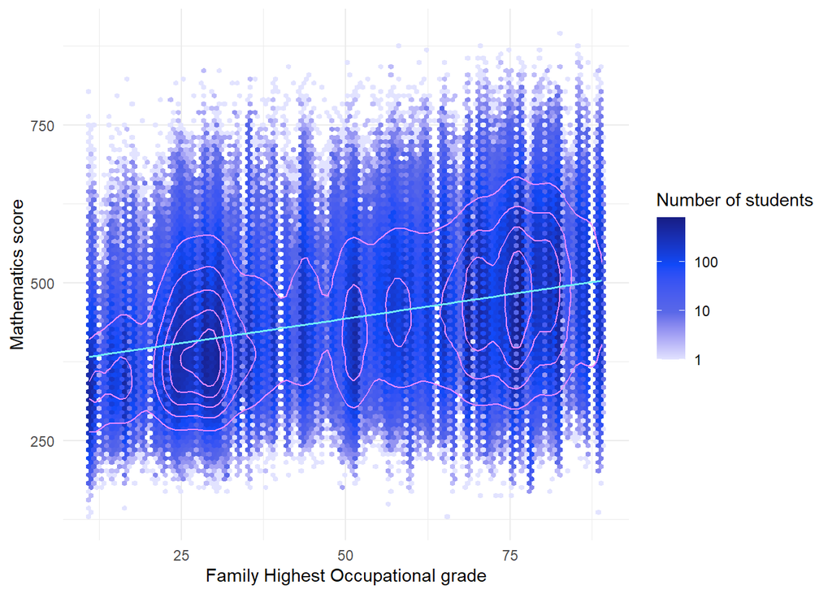

*Note.* This figure is a hexagon bin plot with a simple least-squares linear regression line added, showing the distribution of mathematics scores across family highest occupational grade in the PISA 2025 dataset. Note that the color for number of students is base-10 logarithmic.

The third variable we explored was home ICT resources, representing the relative amount of access each student has to information and communications technology resources at home (OECD, 2026). We visualized the relationship between home ICT resources and mathematics performance via a binned scatterplot, as seen in Figure 4. Here, the trend is more complex, as depicted via the generalized additive model (GAM) smoothing line, and there appears to be a peak of some sort between the values of 0 and 1.5 for home ICT resources index.

### **Figure 4**

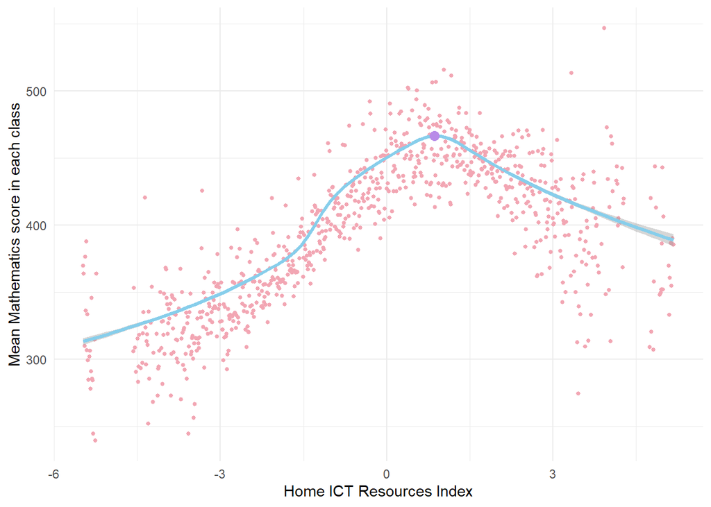

*Note.* This figure shows a binned scatter plot (mean mathematics score plotted for each of 1000 home ICT resources index bins) with a GAM smoothing line shown in blue.

In order to obtain a more concrete and numerical picture of the relationships between each of these three variables and mathematics score, we calculated their (Pearson) correlation coefficients, as seen in Figure 5. As we predicted from the previous figures, each of the variables has positive correlation with the mathematics score. The parental occupation was calculated to have the highest correlation coefficient, followed by home ICT resources and then highest parental education, though they are all quite close together, ranging from 0.33 to 0.36. Since all three correlation coefficients were greater than 0.30, we concluded that moderately strong correlations exist between each of the variables and mathematics score, confirming their potential to be used as predictors to model mathematics score.

### **Figure 5**

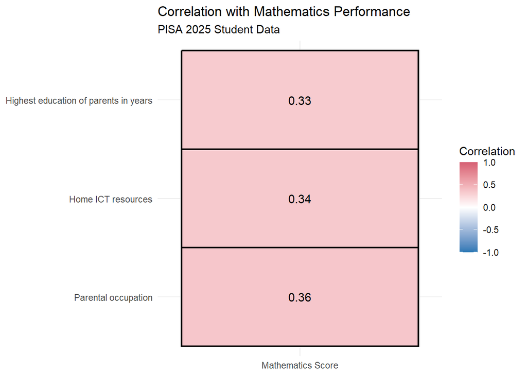

*Note.* This figure shows a correlation heat map for each of the three chosen variables with mathematics score.

### **Multiple linear regression**

We chose a multiple linear regression model, since there are multiple predictors and the outcome (mathematics score) is a continuous numerical variable. As stated above, we chose to use all three of the variables we analyzed as predictors due to their significant correlation with mathematics performance: highest education of parents in years, home ICT resources index, and family highest occupation grade. Running a simple ordinary least squares model, we obtained the following model equation:

$$\widehat{MathScore}_i =
{348.82} +
{0.83} \times Occupation_i +
{3.99} \times Education_i +
{16.70} \times ICT_i,$$

with a multiple R-squared value of 0.1910. This means that this linear regression model explains about 19.10% of variability in mathematics scores, which is quite low.

To improve on this, we chose to added another predictor to the model: since PISA 2025 is intended to investigate the education of students across many countries around the world, we added country as a categorical predictor to the multiple linear regression model, obtaining the following equation:

$$\widehat{MathScore}_i =
{354.89} +
{0.78} \times Occupation_i +
{4.30} \times Education_i +
{5.43} \times ICT_i +
\alpha_{Country(i)},$$

with a multiple R-squared value of 0.4612. This means that this updated multiple linear regression model explains about 46.12% of variability in mathematics scores.

However, to compare the two linear models properly, we must use adjusted r-squared instead, since the normal r-squared typically increases when predictors are added.

The first model (without the country predictor) had an adjusted r-squared of 0.1910, while the second (with the country predictor) had an adjusted r-squared of 0.4611. This indicates that adding the country variable as a predictor heavily improved the prediction capabilities of the model.

## Limitations

The most significant limitation of the data in terms of its suitability for analysis was its student-reported nature: for example, students were expected to report their parents’ highest level of education. However, past studies conducted on previous iterations of PISA, in which parents were also asked to report their education levels (this was not a part of the 2025 questionnaires), found large discrepancies between student and parents’ responses (Jerrim et al., 2024). Since parents’ self-reported level of education is not included in PISA 2025, it is not possible to identify to what extent this affected the dataset.

## Conclusion

Our original research question was investigating how the explanatory variables of parental education, parental occupational status, and home ICT resources are associated with students’ mathematics performance in PISA 2025. Via data visualizations and correlation analysis, we identified a significant positive association between each of the three variables and mathematics score. Consequently, we were able to create a predictive model for the outcome of mathematics score using multiple linear regression, and further improved significantly upon the resulting model by adding country as a categorical predictor (and thus took advantage of the data set’s international scope). Despite certain limitations of the dataset, our analyses support the conclusion in response to our research question that parental education, parental occupational status, and home ICT resources are positively correlated with mathematics performance in PISA 2025, and, furthermore, that these relationships have the potential to be used in predictive modelling.

## References

Jerrim, J. & Zieger, L. (2024). How robust are socio-economic achievement gradients using PISA data? A case study from Germany. British Educational Research Journal, 50, 438–453. https://doi.org/10.1002/berj.3934

OECD. (n.d.). *PISA 2025 student questionnaire data file* [Data set]. Retrieved October 28, 2026, from https://webfs.oecd.org/pisa2022/index.html

OECD (2026), PISA 2025 Results (Volume I): Future-Ready Students, PISA, OECD Publishing, Paris, https://doi.org/10.1787/73451bc5-en.